# Part II - (US Flights of 2008)

## by (Khawla Alqarni)

## Investigation Overview

Exploring US flights of 2008 and answering on:-

- what is the percentage causes of Delayed flights?
- is the Departure Delay normally distributed ?
- Which Airport have largest number of Flights?
- Is Departure delay lead to Arrival delay?
- What is the number of Delay in each Airline by Months and total flights?
- what are the reaons of cancellation in each Airline?
- What is the Average Flights Diverted by months and weekdays?

## Dataset Overview

> The 2009 ASA Statistical Computing and Graphics Data Expo consisted of flight arrival and departure details for all commercial flights on major carriers within the USA, from October 1987 to April 2008.

## what is the percentage causes of Delayed flights?

```
Text(0.5,1,'The percentage of Arrival Delay Flights')
```

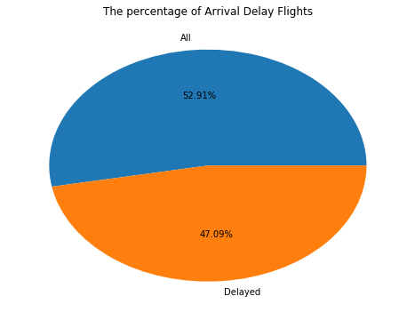

## Is the Departure delay normally distributed ?

> The histogram show that the distribution of departure delay is right skewed.

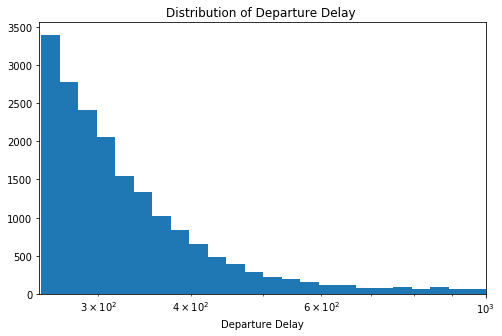

## Which Airport have largest number of Flights?

> Southwest Airline Co (WN) have a huge number of flights which is double other Airlines

```
Text(0.5,0,'Airport code')
```

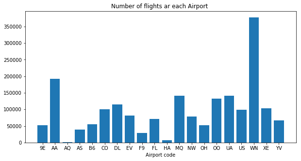

## Is Departure delay lead to Arrival delay?

> From the graph it seems like when Departure delay occure; the Arrival delay occure also. I computed their correlation and it is 95% !! which prove our observation

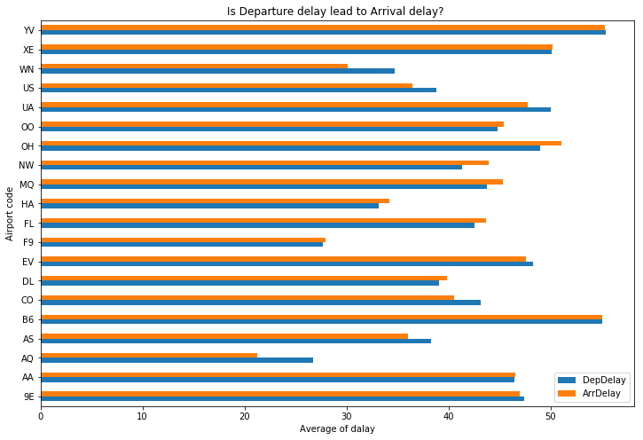

## What is the number of Delay in each Airline by Months and total flights?

> the visualization present only the last three months of the year, may be the delayed information of other months not provided in our data

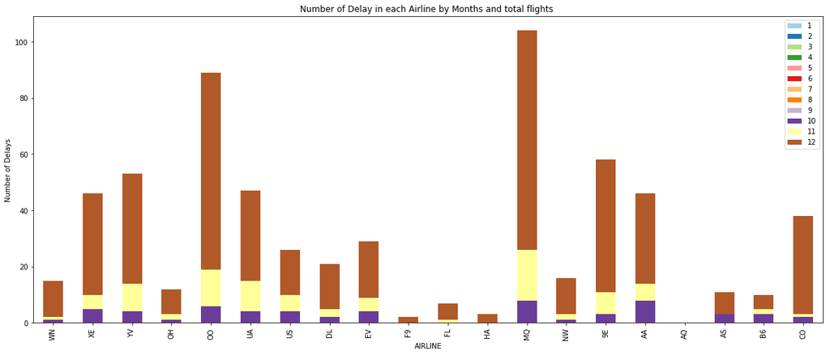

## what are the reaons of cancellation in each Airline?

> American Eagle Airlines Inc (MQ) have a large number of cancelation by wheather and NAS

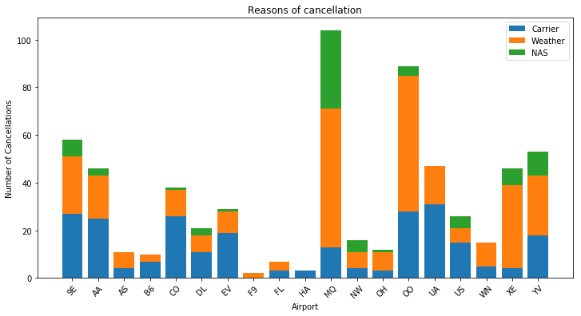

## What is the Average Flights Diverted by months and weekdays?

> Friday in December have the largest rate of flights diverted, next Dec-Tuesday and Jun-Saturday

```
[Text(0.5,1,'Average Flights Diverted by months and weekdays')]
```

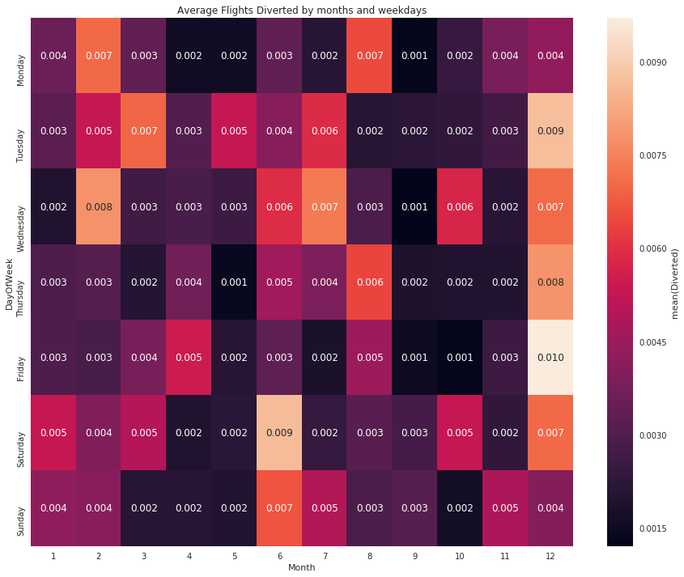